```python
# 블로그에 포스팅하기 위한 스타일 조정
from IPython.core.display import display, HTML
display(HTML("<style> .container{width:90% !important;}</style>"))
```

```python
import pandas as pd
from pandas import Series, DataFrame
import numpy as np
```

# 6.Pandas DataFrame 통계

DataFrame의 주요한 통계 함수는 아래와 같다.

- Describe : 전체 주요 통계량 출력
- sum : 합계 출력
- cumsum : 누적합계 출력
- mean : 평균값 출력
- Std : 표준 편차 출력
- var : 분산 출력
- median : 중앙값 출력
- count : 데이터 개수 출력
- min, max, idxmin, idxmax : 최소값,최대값,최소값의 index, 최대값의 index 출력
- corr, cov : 상관계수, 공분산 출력

위의 통계 함수를 비롯한 대부분의 함수에서 axis 옵션을 이용해 사용할 축을 설정할 수 있다.

- axis = 0 : 열방향으로 통계량 산출(Default)
- axis = 1 : 행방향으로 통계량 산출

실습을 위해 Fifa19 선수들의 Stat 정보를 Load

```python
players = pd.read_csv('data/Ch6_1_fifaStats.csv', index_col = 'Name')
players.head()
```

| Name | ShortPassing | Dribbling | LongPassing | BallControl |
| --- | --- | --- | --- | --- |
| L. Messi | 90.0 | 97.0 | 87.0 | 96.0 |
| Cristiano Ronaldo | 81.0 | 88.0 | 77.0 | 94.0 |
| Neymar Jr | 84.0 | 96.0 | 78.0 | 95.0 |
| De Gea | 50.0 | 18.0 | 51.0 | 42.0 |
| K. De Bruyne | 92.0 | 86.0 | 91.0 | 91.0 |

## 6.1 전체 통계량 요약 보기(describe)

describe 함수 : 컬럼별 전체 통계량을 요약해서 볼 수 있다.

- 데이터 개수, 평균, 표준편차, 최소값, 4분위값, 최대값 출력
- 숫자형 컬럼만 통계량을 출력함

```python
players.describe()
```

|  | ShortPassing | Dribbling | LongPassing | BallControl |
| --- | --- | --- | --- | --- |
| count | 18159.000000 | 18159.000000 | 18159.000000 | 18159.000000 |
| mean | 58.686712 | 55.371001 | 52.711933 | 58.369459 |
| std | 14.699495 | 18.910371 | 15.327870 | 16.686595 |
| min | 7.000000 | 4.000000 | 9.000000 | 5.000000 |
| 25% | 54.000000 | 49.000000 | 43.000000 | 54.000000 |
| 50% | 62.000000 | 61.000000 | 56.000000 | 63.000000 |
| 75% | 68.000000 | 68.000000 | 64.000000 | 69.000000 |
| max | 93.000000 | 97.000000 | 93.000000 | 96.000000 |

## 6.2 함수별 통계량 보기

### 6.2.1 sum():합계 출력

```python
players.sum()
```

```
ShortPassing    1065692.0
Dribbling       1005482.0
LongPassing      957196.0
BallControl     1059931.0
dtype: float64
```

### 6.2.2 cumsum():누적합계 출력

```python
# 선수별 능력치 누적 합계 출력
players.head().cumsum(axis = 1)
```

| Name | ShortPassing | Dribbling | LongPassing | BallControl |
| --- | --- | --- | --- | --- |
| L. Messi | 90.0 | 187.0 | 274.0 | 370.0 |
| Cristiano Ronaldo | 81.0 | 169.0 | 246.0 | 340.0 |
| Neymar Jr | 84.0 | 180.0 | 258.0 | 353.0 |
| De Gea | 50.0 | 68.0 | 119.0 | 161.0 |
| K. De Bruyne | 92.0 | 178.0 | 269.0 | 360.0 |

### 6.2.3 mean(): 평균값 출력

- Stat별 평균(컬럼 기준)

```python
players.mean()
```

```
ShortPassing    58.686712
Dribbling       55.371001
LongPassing     52.711933
BallControl     58.369459
dtype: float64
```

- 선수별 평균(행 기준)

```python
players.mean(axis=1).head()
```

```
Name
L. Messi             92.50
Cristiano Ronaldo    85.00
Neymar Jr            88.25
De Gea               40.25
K. De Bruyne         90.00
dtype: float64
```

### 6.2.4 std(): 표준편차 출력

```python
players.std()
```

```
ShortPassing    14.699495
Dribbling       18.910371
LongPassing     15.327870
BallControl     16.686595
dtype: float64
```

### 6.2.5 var():분산 출력

```python
players.var()
```

```
ShortPassing    216.075157
Dribbling       357.602135
LongPassing     234.943613
BallControl     278.442466
dtype: float64
```

### 6.2.6 median():중앙값 출력

```python
players.median()
```

```
ShortPassing    62.0
Dribbling       61.0
LongPassing     56.0
BallControl     63.0
dtype: float64
```

### 6.2.7 count() : 데이터 개수 출력

```python
players.count()
```

```
ShortPassing    18159
Dribbling       18159
LongPassing     18159
BallControl     18159
dtype: int64
```

### 6.2.8 max(), min() : 최대값, 최소값 출력

```python
players.max()
```

```
ShortPassing    93.0
Dribbling       97.0
LongPassing     93.0
BallControl     96.0
dtype: float64
```

```python
players.min()
```

```
ShortPassing    7.0
Dribbling       4.0
LongPassing     9.0
BallControl     5.0
dtype: float64
```

### 6.2.9 idxmin(), idxmax():최대값,최소값에 해당하는 인덱스 출력

- 선수별 가장 낮은 능력치는?

```python
players.idxmin(axis = 1).head()
```

```
Name
L. Messi             LongPassing
Cristiano Ronaldo    LongPassing
Neymar Jr            LongPassing
De Gea                 Dribbling
K. De Bruyne           Dribbling
dtype: object
```

- 스탯별 최고의 선수는?

```python
players.idxmax()
```

```
ShortPassing    L. Modrić
Dribbling        L. Messi
LongPassing      T. Kroos
BallControl      L. Messi
dtype: object
```

### 6.2.10 corr(), cov(): 상관계수, 공분산 출력

- 전체 컬럼별 상관계수 행렬 출력

```python
corr_mat = players.corr()
corr_mat
```

|  | ShortPassing | Dribbling | LongPassing | BallControl |
| --- | --- | --- | --- | --- |
| ShortPassing | 1.000000 | 0.843722 | 0.895722 | 0.911451 |
| Dribbling | 0.843722 | 1.000000 | 0.722465 | 0.938942 |
| LongPassing | 0.895722 | 0.722465 | 1.000000 | 0.788650 |
| BallControl | 0.911451 | 0.938942 | 0.788650 | 1.000000 |

- 특정 컬럼과 상관도가 높은 순서대로 출력

```python
corr_mat['ShortPassing'].sort_values(ascending = False)
```

```
ShortPassing    1.000000
BallControl     0.911451
LongPassing     0.895722
Dribbling       0.843722
Name: ShortPassing, dtype: float64
```

- 전체 컬럼별 공분산 행렬 출력

```python
cov_mat = players.cov()
cov_mat
```

|  | ShortPassing | Dribbling | LongPassing | BallControl |
| --- | --- | --- | --- | --- |
| ShortPassing | 216.075157 | 234.531811 | 201.816840 | 223.564867 |
| Dribbling | 234.531811 | 357.602135 | 209.410657 | 296.282958 |
| LongPassing | 201.816840 | 209.410657 | 234.943613 | 201.712999 |
| BallControl | 223.564867 | 296.282958 | 201.712999 | 278.442466 |

- 특정 컬럼과 공분산이 낮은 순서대로 출력

```python
cov_mat['Dribbling'].sort_values(ascending = True)
```

```
LongPassing     209.410657
ShortPassing    234.531811
BallControl     296.282958
Dribbling       357.602135
Name: Dribbling, dtype: float64
```

## 6.3 통계량 시각화하기

### 6.3.1 histogram 시각화

```
array([[<matplotlib.axes._subplots.AxesSubplot object at 0x000001611B2ADCC0>,
      dtype=object)
```

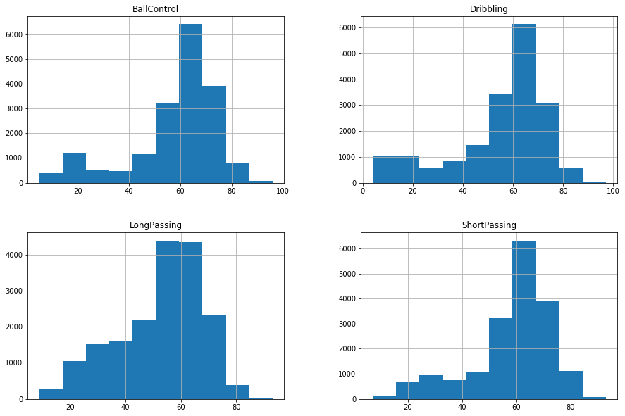

```python
players.hist(figsize = (15,10))
```

### 6.3.2 상관계수 그래프 시각화

```
array([[<matplotlib.axes._subplots.AxesSubplot object at 0x000001611B2625F8>,
      dtype=object)
```

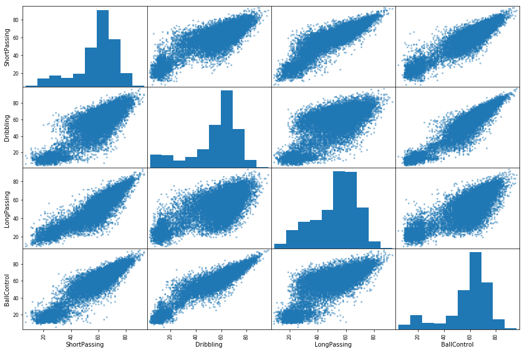

```python
pd.plotting.scatter_matrix(players, figsize = (15,10))
```